# Estimation of population parameters in EL-SILC with the R packages: the experience of ELSTAT

Mnimatidou Anastasia & Sarantou Irene

2024-11-29

### **Introduction: The Transition of ELSTAT from SAS macro ‘Calmar’ to R package ‘icarus’**

The Hellenic Statistical Authority (ELSTAT) has transitioned from the SAS macro ‘Calmar’ to the `icarus` package in R for calibrating EL-SILC survey data, marking a successful shift to modern, open-source data analysis tools. This transition highlights the advantages of R over SAS, including:

- **No licensing fees**, ensuring free accessibility.
- A large, active community that provides ongoing support, updates, and comprehensive documentation.
- Advanced capabilities for **statistical analysis**, **testing**, and **visualization**, which improve the depth and clarity of results.

Additionally, the `icarus` package is designed to function similarly to SAS macro ‘Calmar’, maintaining a comparable interface. This ensures an **easy transition** for users familiar with ‘Calmar’, minimizing the need for extensive training.

This decision is further supported by:

- Demonstrating that the discrepancies between the calibrated weights obtained from these software tools are **statistically insignificant**.
- Providing **visualizations** to aid understanding.

### **Part 1: Steps for Calibration**

Part 1 covers the key steps for calibrating survey data using the R icarus package. We will prepare the necessary inputs, set calibration bounds, configure parameters, and run the calibration process.

#### **Step 1: Preparing Data for Calibration**

**Survey data** and **population margins** are essential inputs for calibration. Both need to be correctly formatted for compatibility with the `icarus` package. For more information, refer to the [icarus package guidelines](https://cran.r-project.org/web/packages/icarus/icarus.pdf).

- **Survey Data**
  - Contains auxiliary variables and initial weights.
  - Must be formatted as a **data frame**.
- **Population Margins**
  - Define target totals for auxiliary variables.
  - Must be formatted as a **matrix**.
  - Required matrix format:

Table 1: Illustration of Calibration Margins Format

|  | Variable_Name | Detail1 | Detail2 | Detail3 | Detail4 |
| --- | --- | --- | --- | --- | --- |
| mar1 | Auxiliary Variable 1 | … | … | … | … |
| mar2 | Auxiliary Variable 2 | … | … | … | … |
| mar3 | Auxiliary Variable 3 | … | … | … | … |
| mar4 | Auxiliary Variable 4 | … | … | … | … |
| mar5 | Auxiliary Variable 5 | … | … | … | … |

**Loading Data Inputs**

```r
# Load the necessary packages for importing and formatting data
library(dplyr)         # For data manipulation
library(openxlsx)      # For reading/writing Excel files

# Load survey data from an Excel file and convert to data frame
main_data <- read.xlsx("SurveyData.xlsx") %>% as.data.frame()

# Load population margins and convert to matrix
population_margins <- read.xlsx("Margins.xlsx") %>% as.matrix()
```

**Note:** Before proceeding with the calibration process, it is important to ensure that:

- **Variable types** are correctly defined (e.g., **numeric values** should not be treated as characters).
- **Why?** Mismatched types may affect the accuracy of the results.

#### **Step 2: Setting Calibration Bounds**

```r
# Define the bounds for the weights
lower_bound <- 0.6
upper_bound <- 2
```

#### **Step 3: Configuring Calibration Parameters**

Define the parameters for the calibration:

- `maxIter`: Sets the maximum number of iterations the calibration algorithm will attempt to reach convergence. Higher values may be necessary for complex data, but excessive iterations can increase computation time without significant benefits. The aim is to balance sufficient attempts with efficiency.
- `calibTolerance`: Tolerance level for precision in meeting calibration constraints. A smaller value (e.g., 0.0000001) ensures high accuracy but can increase computation time.

```r
# Define the parameters for the calibration
max_iterations <- 50
tolerance <- 0.0000001
```

#### **Step 4: Running the Calibration Process**

Apply the `calibration()` function from the `icarus` package with `method = "logit"` to compute calibrated weights based on the population margins dataset we have provided.

```r
# Load the required packages
library(icarus)

# Perform calibration using icarus package
calibrated_weights <- calibration(data=main_data,
                                  marginMatrix=population_margins,
                                  colWeights="weight",
                                  method="logit",
                                  bounds=c(lower_bound,upper_bound),
                                  maxIter = max_iterations,
                                  calibTolerance = tolerance)
```

## **Part 2: Comparison of results (R vs SAS)**

In **Part 2**, we compare the R package `icarus` and the SAS macro ‘Calmar’, focusing on the following key aspects:

- **Summary Statistics:** Analyzing the absolute differences between the calibrated weights produced by both tools.
- **Visualizations:** Using dot plots, histograms, and Q-Q plots to highlight any discrepancies.
- **Findings:** Demonstrating the minimal differences between the calibrated weights obtained from these two software tools.
- **Validation:** Confirming `icarus` as a reliable, cost-effective, and open-source alternative for calibration tasks.

**Note**: The same data, bounds, and values for the calibration parameters were applied in the calibration process for both the SAS macro ‘Calmar’ and the R package `icarus` to ensure a **fair comparison**.

To initiate the comparison, we load the calibrated weights obtained using ‘Calmar’ (SAS):

```r
calibrated_weights_SAS <- read.xlsx("CalibratedWeights_SAS.xlsx")
```

### **1. Comparing Results: Absolute Differences Between Calibrated Weights**

In this section, we examine the absolute differences between the calibrated weights obtained from the two calibration tools: one using R’s `icarus` package and the other using the SAS macro ‘Calmar’. We calculate the absolute discrepancies as follows:

```r
# Compare calibrated weights
calibrated_weights_comparison <- data.frame(
  Household_ID = main_data$id,
  Absolute_Differences = round(abs(calibrated_weights - calibrated_weights_SAS), 6)
)
```

To provide an interactive visualization of the differences:

|  | Household_ID | Absolute_Differences |
| --- | --- | --- |
| 1 | 823850 | 7e-06 |
| 2 | 823860 | 1.8e-05 |
| 3 | 823870 | 6.6e-05 |
| 4 | 823880 | 1.8e-05 |
| 5 | 823890 | 6e-06 |
| 6 | 823900 | 9e-06 |
| 7 | 823910 | 6e-06 |
| 8 | 823920 | 2e-06 |
| 9 | 823930 | 5e-06 |
| 10 | 823940 | 6.7e-05 |

[output cut: 10707 more lines]

#### **Statistical Summary of the Differences**

To provide a more detailed overview, we present the summary statistics of the absolute differences:

Table 3: Statistical Summary of Differences

| Statistic | Value |
| --- | --- |
| Maximum Absolute Difference | 1.87e-04 |
| Mean Absolute Difference | 1.04e-05 |
| Standard Deviation of Differences | 1.17e-05 |

The observed **Maximum Absolute Difference** of **1.87e-04**, paired with a **Mean Absolute Difference** of **1.04e-05** and a **Standard Deviation** of **1.17e-05**, clearly demonstrate that the discrepancies between the two calibration tools are **negligible**.

These minimal differences strongly suggest that `icarus` is a reliable, cost-effective, and open-source alternative to SAS macro ‘Calmar’ for calibration tasks.

### **2. Comparing Results: Visualizing Statistical Insights in R**

To further enhance the comparison, we present visualizations that illustrate the results from both R (`icarus`) and SAS (‘Calmar’). By comparing the plots side by side, we can visually assess the minimal discrepancies between the two calibration tools, confirming that the results from both platforms are virtually indistinguishable.

To proceed with the visualizations, we construct a dataframe containing the calibrated weights produced by both methods and load the ggplot2 package, which will be used to generate the visualizations:

```r
# Combine data for analysis
results <- data.frame(
  id = main_data$id,
  calibrated_weights_R = calibrated_weights,
  calibrated_weights_SAS = calibrated_weights_SAS
)

# Load the required packages
library(ggplot2)
```

#### **Plot 1: Dot Plot of Calibrated Weights**

The dot plot below displays the calibrated weights obtained from R (blue circles) and SAS (triangles) for each household ID. The overlap of points demonstrates that the calibrated weights from both tools are closely aligned, reinforcing the similarity of results between R and SAS.

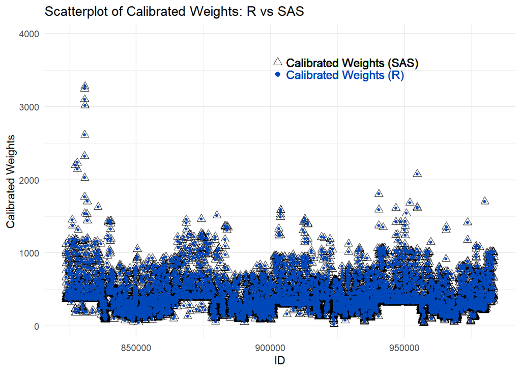

**Illustrative Code for R Plot:**

```r
# Create a dot plot of the calibrated weights produced by R using the icarus package
plot1 <- ggplot(results, aes(x = id)) +
  geom_point(aes(y = calibrated_weights_R, group = id), color = "#674ea7") +
  labs(title = "Scatterplot of Calibrated Weights (R)",
       x = "ID",
       y = "Calibrated Weights"
       ) +
  theme_minimal()

# Print the plot
print(plot1)
```

#### **Plot 2: Histogram of Calibrated Weights**

The histograms below illustrate the distribution of calibrated weights for both tools. The overlap in shapes between R’s and SAS’s histograms confirms that both methods yield similar distributions, reinforcing the equivalence of the results.

**Comparison Plots (R vs SAS):**

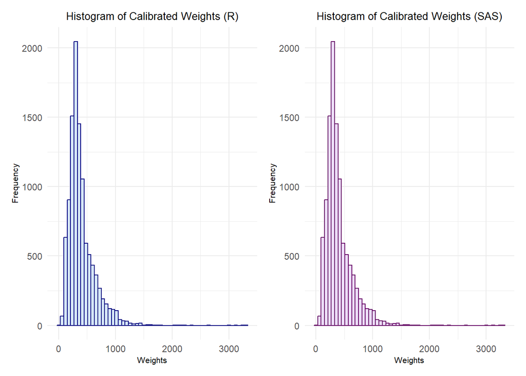

**Illustrative Code for R Plot:**

```r
# Create a histogram of the calibrated weights produced by R using the icarus package
plot2 <- ggplot(results, aes(x = calibrated_weights_R)) +
  geom_histogram(binwidth = 60, fill = "#d7e8f7", color = "#000080") +
  labs(title = "Histogram of Calibrated Weights (R)",
       x = "Weights",
       y = "Frequency"
       ) +
  theme_minimal()

# Print the plot
print(plot2)
```

#### **Plot 3: Q-Q Plot of Calibrated Weights**

**Comparison Plots (R vs SAS):**

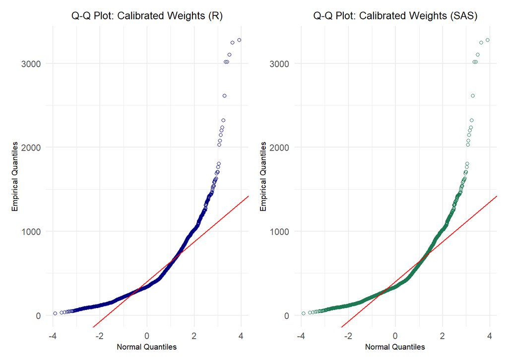

**Illustrative Code for R Plot:**

```r
# Sort the empirical data
empirical_quantiles <- sort(results$calibrated_weights_R)

# Calculate the normal quantiles for the same number of observations
n <- length(empirical_quantiles)
normal_quantiles <- qnorm(ppoints(n))

# Create a data frame for plotting
qq_plot_data <- data.frame(normal_quantiles, empirical_quantiles)

# Create a Q-Q plot of the calibrated weights produced by R using the icarus package
plot3 <- ggplot(qq_plot_data, aes(x = normal_quantiles, y = empirical_quantiles)) +
  geom_point(shape = 1, color = "#000080") +
  geom_abline(intercept = mean(results$calibrated_weights_R),
              slope = sd(results$calibrated_weights_R),
              color = "red") +
  labs(title = "Q-Q Plot of Calibrated Weights",
       x = "Normal Quantiles",
       y = "Empirical Quantiles of Calibrated Weights"
       ) +
  theme_minimal()

# Print the plot
print(plot3)
```

#### **Plot 4: Boxplot of Calibrated Weights**

The boxplots visually compare the distribution and central tendency of the calibrated weights for R and SAS. The boxplots for both methods show similar medians, interquartile ranges, and overall distributions, reinforcing the equivalence between the two approaches.

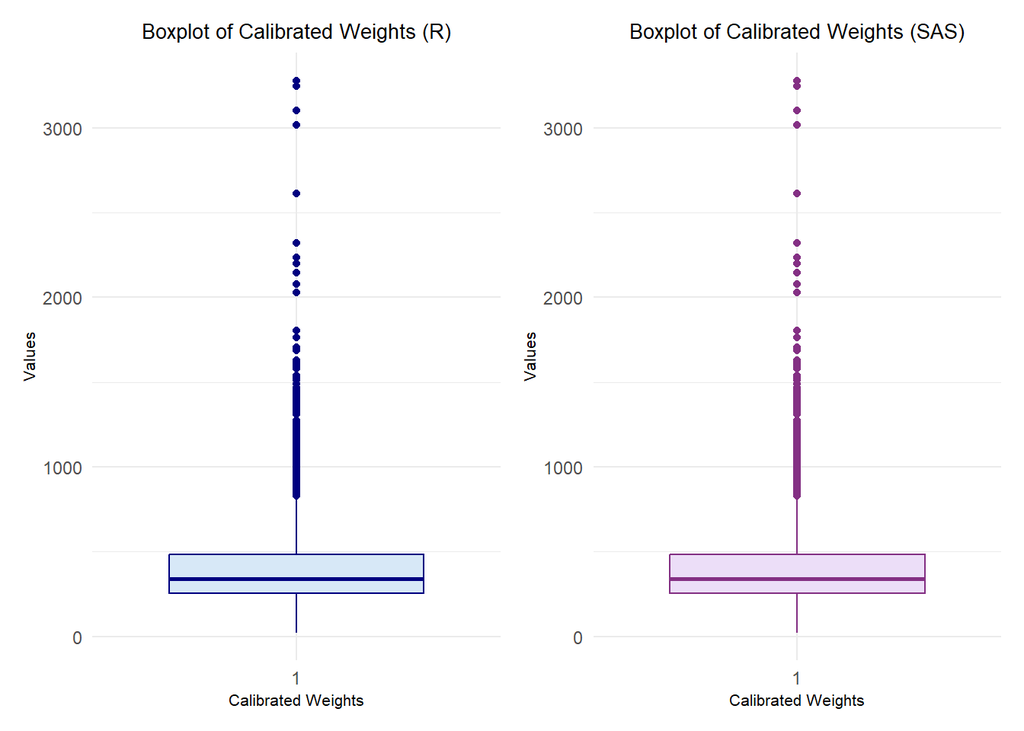

**Illustrative Code for R Plot:**

```r
# Create a boxplot of the calibrated weights produced by R using the icarus package
plot4 <- ggplot(results, aes(x = factor(1), y = calibrated_weights_R)) +
  geom_boxplot(fill = "#d7e8f7", color = "#000080") +
  labs(title = "Boxplot of Calibrated Weights (R)",
       x = "Calibrated Weights",
       y = "Values"
       ) +
  theme_minimal()

# Print the plot
print(plot4)
```

### **Conclusion**

The transition from ELSTAT’s use of SAS ‘Calmar’ to R’s `icarus` package marks a significant achievement in terms of both **methodological consistency** and **cost-efficiency**. This move highlights the power of open-source software for statistical analysis in official statistics.

- **No Licensing Fees:** R eliminates the need for expensive licensing fees, making it a cost-effective alternative to proprietary software like SAS.
- **Supportive Community:** R has an active community providing continuous support, ensuring sustainability.
- **Advanced Analysis & Visualization:** R, as an open-source software, provides advanced statistical analysis and robust visualization tools, enhancing data insights.
- **Seamless Transition:** The interface of `icarus` is similar to SAS ‘Calmar’, minimizing the need for retraining.
- **Statistical Validation:** The results from R’s `icarus` package are nearly identical to SAS ‘Calmar’, ensuring reliability and accuracy.

In conclusion, the move to R’s icarus package not only reduces costs but also preserves the accuracy and integrity of ELSTAT’s statistical processes. This transition underscores the potential of open-source software in official statistics, making it an excellent model for other institutions to modernize their data analysis practices.

### **References**

Deville, J.-C., & Särndal, C.-E. (1992). Calibration estimators in survey sampling. Journal of the American Statistical Association, 87(418), 376–382. https://doi.org/10.1080/01621459.1992.10475217

Sautory, O. (1993). La macro ‘Calmar’: Redressement d’un échantillon par calage sur marges. Document de travail F9310 de la DSDS, Insee.

Templ, M., & Todorov, V. (2016). The Software Environment R for Official Statistics. Austrian Journal of Statistics, 45(2), 97–124. https://doi.org/10.17713/ajs.v45i1.100

Rebecq, A. (2016). Icarus : un package R pour le calage sur marges et ses variantes. In 9eme Colloque francophone sur les sondages (Gatineau, Canada, 2016).

Rebecq, A. (2023). Icarus: R package version 0.3.2. Retrieved from https://cran.r-project.org/web/packages/icarus/icarus.pdf